# James Chan

## About Me

Mostly writing [R code](https://github.com/jachan1?tab=repositories) and analyzing data.

[Linkedin](https://www.linkedin.com/in/james-chan-26826763) always has more work details.

Research projects I’ve worked on via [NCBI](http://www.ncbi.nlm.nih.gov/sites/myncbi/1TuT66tvRkGAm/bibliography/50039412/public/?sort=date&direction=ascending)

## Quick Look

### Bootstrapping Joint Model

Fitting a linear mixed effects model with vcp as the outcome and time prior to procedure as the only covariate gives useful information about individual estimate for vcp at time of procedure and average change in vcp per month prior to procedure. The random intercept and slope are of most interest here. These random effects can then be used as covariates in a survival post procedure model. This has the benefit of filling in gaps for vcp prior to procedure and also adding in information about the rate of change prior to procedure. These models can be fit separately but then the joint error needs to be estimated. The method shown below uses bootstrapping to calculate non-parametric errors for the effects of interest.

```r
jm_fxn <- function(data, b, formula, covs=NULL, long_ds, var){
  d = data[b, ]
  get_coefs <- function(){
    d$new_id <- sprintf("%0*d", nchar(nrow(d)), 1:nrow(d))
    ## the long dataset needs to be restricted to subjects bootstrapped. Since the IDs can repeat
    tmp_ds <- d %>% select(new_id, subject_id) %>% left_join(long_ds, by="subject_id") %>% select(-subject_id)

    ## mixed model is used to estimate an intercept and slope to use in the final model
    fm_lms <- stats::formula(sprintf("%s ~ months_bp", var))
    lms <- lme(fm_lms, random=~months_bp|new_id, correlation = corAR1(), data=tmp_ds)

    ## this extract estimates
    ## the fixed effect is added to the random effect for each subject to estimate for each subject
    lms_summ <- summary(lms)
    preds_df <- data_frame(new_id=rownames(lms_summ$coefficients$random$new_id),
                           int = lms_summ$coefficients$random$new_id[,"(Intercept)"] +
                             lms_summ$coefficients$fixed["(Intercept)"],
                           slope=lms_summ$coefficients$random$new_id[,"months_bp"] +
                             lms_summ$coefficients$fixed["months_bp"])

    ## the string "int" and "slope" should not be in covs
    surv_ds <- d[c("new_id", "surv_months", "event", covs)] %>% left_join(preds_df, by="new_id")

    ## the cox proportional hazard model includes the intercept and slope and any given covariates (cov)
    sf <- stats::formula(sprintf("Surv(surv_months, event) ~ int + %s", paste0("`", "slope", "`", collapse=" + ")))
    cph <- coxph(sf, data=surv_ds)
    scph <- summary(cph)

    ## the bootstrapped statistic is the estimate
    outv <- c(scph$coefficients[c("int", "slope"), "exp(coef)"])
    names(outv) <- paste(var, c("int_unadj", "slope_unadj"), sep="_")
    outv
  }
  tryCatch(get_coefs(), error=function(e) NA)
}

bt_cox_fxn <- function(x, conf=0.95){
  df_out <- data.frame(HR=x$t0)
  df_out$vnames = rownames(df_out)

  ## standard Error
  df_out$se <- apply(x$t, 2, sd, na.rm=T)

  ## P value
  df_out$p <- sapply(1:ncol(x$t), function(i){
    sum(sign(x$t0[i])*x$t[,i] > sign(x$t0[i]), na.rm=T)/sum(!is.na(x$t[,i]))
  })

  ## Confidence interval
  df_out[c("Lower 95%", "Upper 95%")] <- t(apply(x$t, 2, function(y){
    quantile(y, c((1-conf)/2, 1-(1-conf)/2), na.rm=T)
  }))
  df_out
}

### Example Code ---
## number of bootstraps (low for example. 2000 used for analysis)
bnum=1000

## creating fake data
subs <- sprintf("%03d", 1:100) ## subject ID
time_pr <- 1:10 ## time before procedure

## vcp_ds is a generated dataset that shows the trajectory of vcp prior to procedure
vcp_ds <- expand.grid(subject_id=subs, months_bp=time_pr, stringsAsFactors=F) %>%
  group_by(subject_id) %>% arrange(-months_bp) %>%
  mutate(vcp = runif(1, 80, 100) - seq(runif(1, 0, 10), runif(1, 20, 60), length.out=n()) + runif(n(), -5, 5))

## s_ds is a generated dataset that shows the survival post procedure
s_ds <- vcp_ds %>% arrange(subject_id, months_bp) %>% filter(row_number() == 1) %>%
  mutate(Tlat=-log(runif(n=n())) / (0.01 * exp(rbinom(n(), 1, 0.5)*-0.6)),
         c=rexp(n(), 0.001),
         surv_months = pmin(Tlat, c),
         event=as.numeric(Tlat <= c))

## running boot function
bt <- boot(data=s_ds, statistic=jm_fxn, R=bnum, long_ds=vcp_ds, var="vcp")
```

Resulting effects and confidence intervals below

|  | HR | se | p | Lower 95% | Upper 95% |
| --- | --- | --- | --- | --- | --- |
| VCP Intercept | 1.057 | 0.021 | 1 | 1.022 | 1.107 |
| VCP Slope | 1.835 | 0.464 | 0.999 | 1.227 | 3.101 |

### Plotting Predicted Survival

|  | HR (se) | p |
| --- | --- | --- |
| age | 1.13 (0.05) | 0.01 |
| resid.ds | 2.28 (0.79) | 0.3 |
| rx | 0.40 (0.65) | 0.16 |
| ecog.ps | 1.40 (0.64) | 0.6 |

One option would be to display the Kaplan Meiers curves with an arbitrary (or clinically defined) dichotomization of age. However, this isn’t particularly analogous to the cox model with continuous age and unless the cutoff has a clinical significance the comparison is not very meaningful.

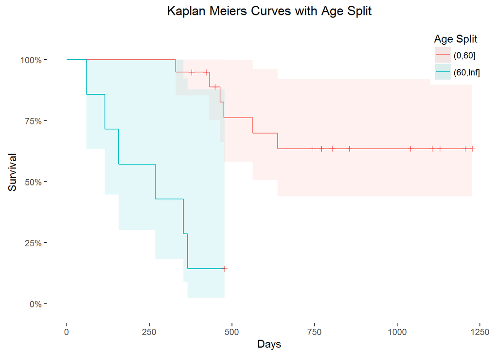

Another option would be to estimate the survival curves using the cox model. This can be done in R by providing the original dataset as newdata to the survfit function and only change the age to obtain appropriately adjusted predictions.

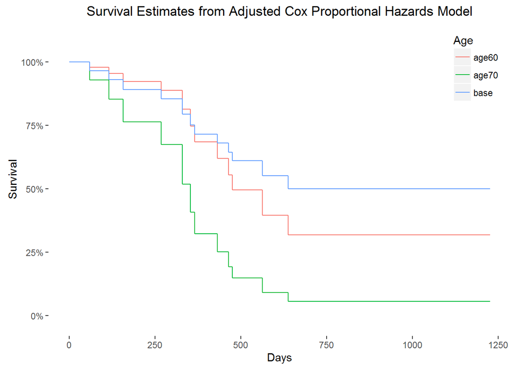